# Climatie Data

Villasenor-Derbez, J.C.

21 de octubre de 2016

## Start and end dates by station

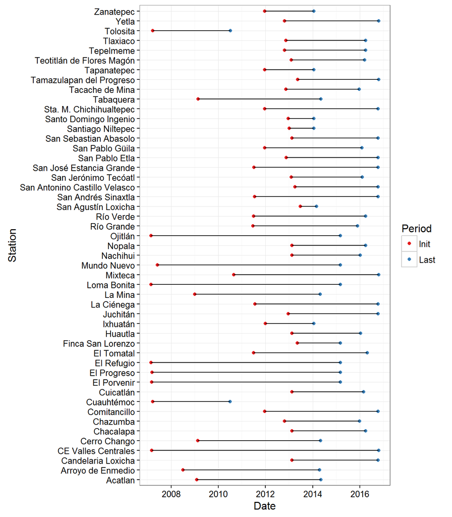

## Frequency of start and end dates

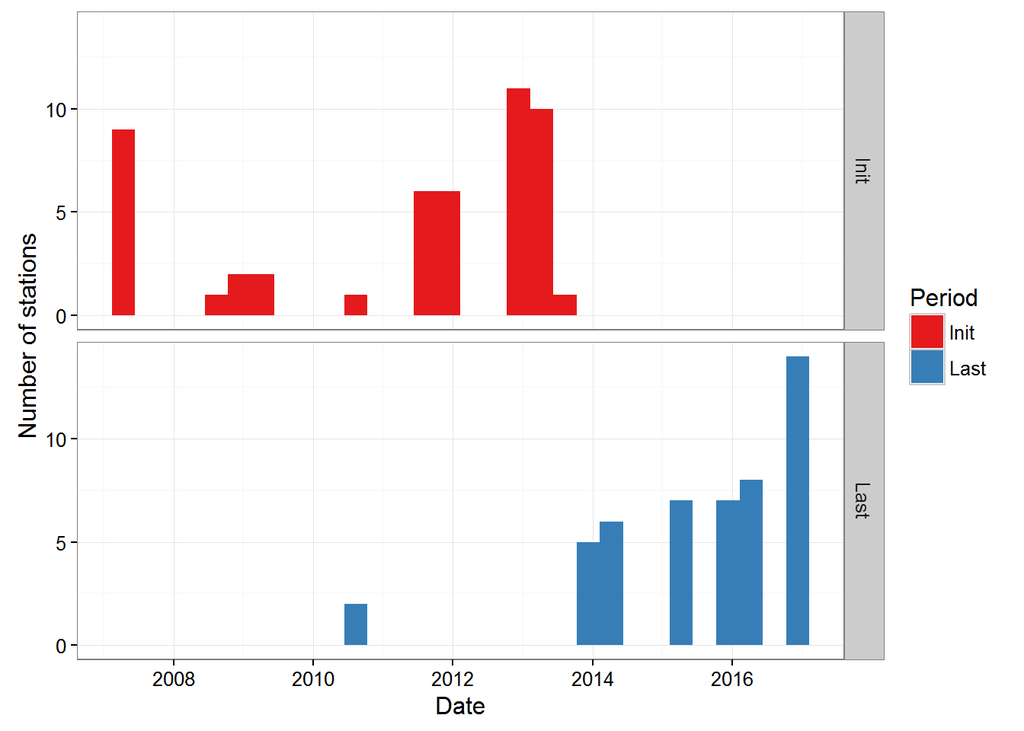

## Leaf rust and climate matches

### Municipalities with leaf rust

## Municipality

Cacahoatan  
Candelaria Loxicha  
Escuintla  
Gueva de Humboldt  
Huautla de Jimenez  
Huehuetán  
Pluma Hidalgo  
San José Tenango  
San Mateo Piñas  
San Mateo Pocutla  
San Miguel Puerto  
San Pedro Pochutla  
Santa Maria Chilchotla Santiago Lachiguiri  
Santiago Xanica  
Tapachula  
Tuxtla Chico  
Tuzantan

### Municipalities with climate data

## Municipality

Villa de Tamazulapam del Progreso  
Acatlán de Pérez Figueroa  
Ciénega de Zimatlán  
Heroica Ciudad de Ejutla de Crespo  
Heroica Ciudad de Tlaxiaco  
Huautla de Jiménez  
Juchitán de Zaragoza  
Loma Bonita  
Matías Romero  
Pluma Hidalgo  
San Agustín Loxicha  
San Andrés Sinaxtla  
San Antonino Castillo Velasco  
San Francisco Ixhuatán  
San Jerónimo Tecoatl  
San José Chiltepec  
San José Estancia Grande  
San Juan Bautista Cuicatlán  
San Juan Bautista Tuxtepec  
San Juan Cotzocón  
San Lucas Ojitlán  
San Miguel Soyaltepec  
San Pablo Etla  
San Pedro Comitancillo  
San Pedro Tapanatepec  
San Sebastian Abasolo  
Santa Cruz Tacache de Mina  
Santa María Colotepec  
Santa María Jacatepec  
Santiago Chazumba  
Santiago Jamiltepec  
Santiago Matatlán  
Santiago Niltepec  
Santiago Yaveo  
Santo Domingo Ingenio  
Santo Domingo Tonalá  
Santo Domingo Yanhitlán  
Santo Domingo Zanatepec  
Santos Reyes Nopala  
Teotitlán de Flores Magón  
Tepelmeme Villa de Morelos  
Villa de Etla  
Villa de Tututepec de Melchor Ocampo Villa Sola de Vega